# Back-related disability (Roland-Morris) in primary-care patients with sciatica

Dataset 3: Sciatica in primary care

RSR feasibility analysis

2026-08-03

# Introduction

Sciatica – leg pain radiating from the back along a nerve-root distribution – is one of the commonest reasons adults consult primary care for back trouble, and the practical question at that first consultation is not usually *what is on the scan* but *how disabled is this patient and why*. These data come from a cross-sectional diagnostic-accuracy study of 395 adults who presented to Dutch general practices with a new episode of sciatica and who underwent a standardised history, physical examination and lumbar MRI (Verwoerd et al.; sciatica in general practice, MRI substudy). Back-related disability is measured with the Roland-Morris Disability Questionnaire (RMDQ), the standard functional outcome in back-pain research, and it drives decisions about sick leave, physiotherapy referral and imaging.

**Aim.** Among primary-care patients presenting with sciatica, we examined which of age, sex, body mass index, back-pain intensity, leg-pain intensity, self-rated general health, comorbidity count and a positive neural-tension test are independently associated with the Roland-Morris disability score, mutually adjusting for the others.

This is a *Purpose 3* analysis: several predictors are of interest and the question is which remain associated with the outcome after mutual adjustment.

# Methods

**Data source.** Cross-sectional baseline data from a primary-care sciatica cohort: 395 adults consulting Dutch general practitioners with a new episode of sciatica, each assessed at a single occasion with a structured symptom questionnaire, a physical examination and a lumbar MRI. Age ranged from 19 to 82 years.

**Variables.** The outcome is `disability_score`, the Roland-Morris Disability Questionnaire total, an integer count of 0-23 endorsed disability items where higher means worse back-related function. Predictors are `age_yrs` (years), `sex` (reference: female, the larger group), `bmi` (kg/m²), `back_pain_intensity` (0-10 numerical rating scale), `leg_pain_intensity` (0-10 numerical rating scale), `general_health` (self-rated; reference: good, the largest group), `comorbidities` (reference: none, the largest group) and `neural_tension_positive` (at least one positive neural-tension test on examination; reference: no).

`id` is a participant label and is excluded from every model. `clinician_sciatica` – the GP’s high-confidence diagnosis of sciatica – is present in the file but is **not** used here. It is a clinician’s summary judgement formed from the very examination findings that are candidate predictors: it correlates 0.61 with `neural_tension_positive`, 0.54 with `below_knee_pain` and 0.49 with `neurological_deficit`. Entering it alongside those signs would put a variable and a summary of that variable in the same model, which makes the individual sign coefficients uninterpretable rather than merely imprecise. The remaining clinical signs (`cough_sneeze_positive`, `below_knee_pain`, `subjective_sensory_changes`, `neurological_deficit`) are omitted from the main model to keep it to eight predictors; `neural_tension_positive` is retained because it is the only examination finding with a clear crude association with disability (r = 0.22).

**Statistical analysis.** Linear regression (`lm()`), justified because the outcome is a 24-point score that is close to symmetric and spread across essentially its whole range, so a continuous approximation is reasonable. We fitted a univariable model for each predictor first, then a single multivariable model containing all of them. Predictors were chosen in advance on subject-matter grounds, not by significance. Significance threshold 0.05; estimates are reported with 95% confidence intervals. Assumptions were checked with `performance::check_model()`, supported by formal tests of heteroscedasticity, residual normality and collinearity; had non-constant variance been detected we would have reported HC3 robust standard errors via `lmtest::coeftest()` with `sandwich::vcovHC()`. Analysis used R version 4.6.0 (2026-04-24) with tidyverse, gtsummary and performance.

**Missing data.** Complete-case analysis: 393 of 395 rows were analysed (2 dropped, 0.5%). Missingness in this file is small but real and confined to three columns: leg_pain_duration (19), bmi (2), back_pain_duration (2). The outcome itself is complete. Only `bmi` (2 missing) is in this model, so the loss here is trivial; a model containing `leg_pain_duration` would instead lose 19 further rows.

# Results

## Sample characteristics

**Table 1. Sample characteristics.**

| **Characteristic** | **N** | **N = 393**<sup>1</sup> |
| --- | --- | --- |
| disability_score | 393 | 13.0 (9.0, 17.0) |
| age_yrs | 393 | 50 (40, 60) |
| sex | 393 |  |
| Female |  | 236 (60%) |
| Male |  | 157 (40%) |
| bmi | 393 | 28.4 (25.5, 32.8) |
| back_pain_intensity | 393 | 5.67 (4.00, 7.00) |
| leg_pain_intensity | 393 | 5.33 (3.67, 7.00) |
| general_health | 393 |  |
| Good |  | 321 (82%) |
| Fair |  | 65 (17%) |
| Poor |  | 7 (1.8%) |
| comorbidities | 393 |  |
| None |  | 249 (63%) |
| One |  | 101 (26%) |
| Two or more |  | 43 (11%) |
| neural_tension_positive | 393 | 239 (61%) |

<sup>1</sup> Median (Q1, Q3); n (%)

The sample is middle-aged (median 50 years), 60% female and overweight on average (median BMI 28.4 kg/m²). Symptoms are moderate to severe: median back-pain and leg-pain intensities are both near 6/10 and the median RMDQ score is 13 of 23, so half the sample reports disability on more than half the questionnaire items. Most rate their general health as good, and only 7 rate it poor – a sparse cell that will matter for that coefficient.

## Exploratory figure

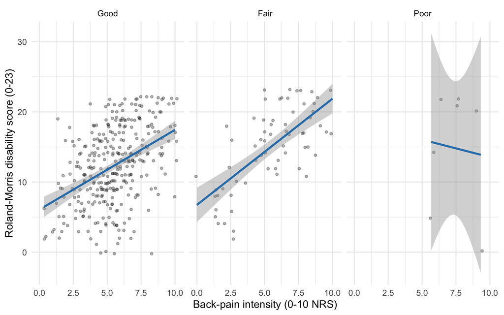

Figure 1. Roland-Morris disability score against back-pain intensity, split by self-rated general health. Lines are linear smooths with 95% confidence bands; points are jittered because both variables are recorded on discrete scales.

## Univariable models

| **Characteristic** | **N** | **Beta** | **95% CI** | **p-value** |
| --- | --- | --- | --- | --- |
| age_yrs | 393 | -0.04 | -0.08, 0.00 | 0.044 |
| sex | 393 |  |  |  |
| Female |  | — | — |  |
| Male |  | -0.07 | -1.2, 1.1 | >0.9 |
| bmi | 393 | 0.19 | 0.10, 0.28 | <0.001 |
| back_pain_intensity | 393 | 1.2 | 0.98, 1.4 | <0.001 |
| leg_pain_intensity | 393 | 1.0 | 0.82, 1.2 | <0.001 |
| general_health | 393 |  |  |  |
| Good |  | — | — |  |
| Fair |  | 2.7 | 1.2, 4.2 | <0.001 |
| Poor |  | 2.6 | -1.6, 6.8 | 0.2 |
| comorbidities | 393 |  |  |  |
| None |  | — | — |  |
| One |  | 0.60 | -0.72, 1.9 | 0.4 |
| Two or more |  | 0.06 | -1.8, 1.9 | >0.9 |
| neural_tension_positive | 393 |  |  |  |
| No |  | — | — |  |
| Yes |  | 2.5 | 1.4, 3.7 | <0.001 |

Abbreviation: CI = Confidence Interval

## Why adjustment is needed

The crude estimates above cannot be read as independent contributions because the symptom variables in this file travel together. `back_pain_intensity` is the clearest confounder of the leg-pain association: it correlates r = 0.61 with `leg_pain_intensity` and r = 0.46 with disability, so a patient with severe leg pain usually also has severe back pain, and the crude leg-pain slope is partly a back-pain slope in disguise. The Roland-Morris questionnaire asks about activities limited “because of my back”, which makes back pain the more direct cause of the score and leg pain the correlate. `general_health` is a second confounder: patients who rate their general health as fair or poor report higher pain intensities (mean back pain 5.7 versus 5.5 in those rating it good) *and* higher disability, so part of the crude pain effect is general ill-health rather than the sciatic episode. `age_yrs` is a third: age is associated with higher BMI (r = 0.1) and with comorbidity count, both of which are plausibly linked to function, so the crude negative age slope and the crude BMI slope each contain some of the other. Adjustment here is what turns “patients with worse leg pain are more disabled” into “at the same level of back pain, general health and body size, patients with worse leg pain are more disabled” – a much more defensible claim.

## Multivariable model

| **Characteristic** | **Beta** | **95% CI** | **p-value** |
| --- | --- | --- | --- |
| age_yrs | -0.05 | -0.09, -0.01 | 0.007 |
| sex |  |  |  |
| Female | — | — |  |
| Male | 0.51 | -0.45, 1.5 | 0.3 |
| bmi | 0.14 | 0.06, 0.22 | <0.001 |
| back_pain_intensity | 0.83 | 0.54, 1.1 | <0.001 |
| leg_pain_intensity | 0.45 | 0.18, 0.71 | <0.001 |
| general_health |  |  |  |
| Good | — | — |  |
| Fair | 2.3 | 0.95, 3.6 | <0.001 |
| Poor | 0.43 | -3.3, 4.2 | 0.8 |
| comorbidities |  |  |  |
| None | — | — |  |
| One | 0.04 | -1.1, 1.2 | >0.9 |
| Two or more | 0.21 | -1.5, 1.9 | 0.8 |
| neural_tension_positive |  |  |  |
| No | — | — |  |
| Yes | 1.5 | 0.47, 2.5 | 0.004 |

Abbreviation: CI = Confidence Interval

Model fit

| Statistic | Value |
| --- | --- |
| R-squared | 0.330 |
| Adjusted R-squared | 0.312 |
| Residual SE | 4.710 |
| N (complete cases) | 393.000 |
| Estimated parameters | 11.000 |
| Observations per parameter | 35.700 |
| AIC | 2345.800 |

## Unadjusted versus adjusted

**Table 2. Unadjusted and adjusted estimates.**

| **Characteristic** | **Unadjusted** **N** | **Unadjusted** **Beta** | **Unadjusted** **95% CI** | **Unadjusted** **p-value** | **Adjusted** **Beta** | **Adjusted** **95% CI** | **Adjusted** **p-value** |
| --- | --- | --- | --- | --- | --- | --- | --- |
| age_yrs | 393 | -0.04 | -0.08, 0.00 | 0.044 | -0.05 | -0.09, -0.01 | 0.007 |
| sex | 393 |  |  |  |  |  |  |
| Female |  | — | — |  | — | — |  |
| Male |  | -0.07 | -1.2, 1.1 | >0.9 | 0.51 | -0.45, 1.5 | 0.3 |
| bmi | 393 | 0.19 | 0.10, 0.28 | <0.001 | 0.14 | 0.06, 0.22 | <0.001 |
| back_pain_intensity | 393 | 1.2 | 0.98, 1.4 | <0.001 | 0.83 | 0.54, 1.1 | <0.001 |
| leg_pain_intensity | 393 | 1.0 | 0.82, 1.2 | <0.001 | 0.45 | 0.18, 0.71 | <0.001 |
| general_health | 393 |  |  |  |  |  |  |
| Good |  | — | — |  | — | — |  |
| Fair |  | 2.7 | 1.2, 4.2 | <0.001 | 2.3 | 0.95, 3.6 | <0.001 |
| Poor |  | 2.6 | -1.6, 6.8 | 0.2 | 0.43 | -3.3, 4.2 | 0.8 |
| comorbidities | 393 |  |  |  |  |  |  |
| None |  | — | — |  | — | — |  |
| One |  | 0.60 | -0.72, 1.9 | 0.4 | 0.04 | -1.1, 1.2 | >0.9 |
| Two or more |  | 0.06 | -1.8, 1.9 | >0.9 | 0.21 | -1.5, 1.9 | 0.8 |
| neural_tension_positive | 393 |  |  |  |  |  |  |
| No |  | — | — |  | — | — |  |
| Yes |  | 2.5 | 1.4, 3.7 | <0.001 | 1.5 | 0.47, 2.5 | 0.004 |

Abbreviation: CI = Confidence Interval

## Diagnostics

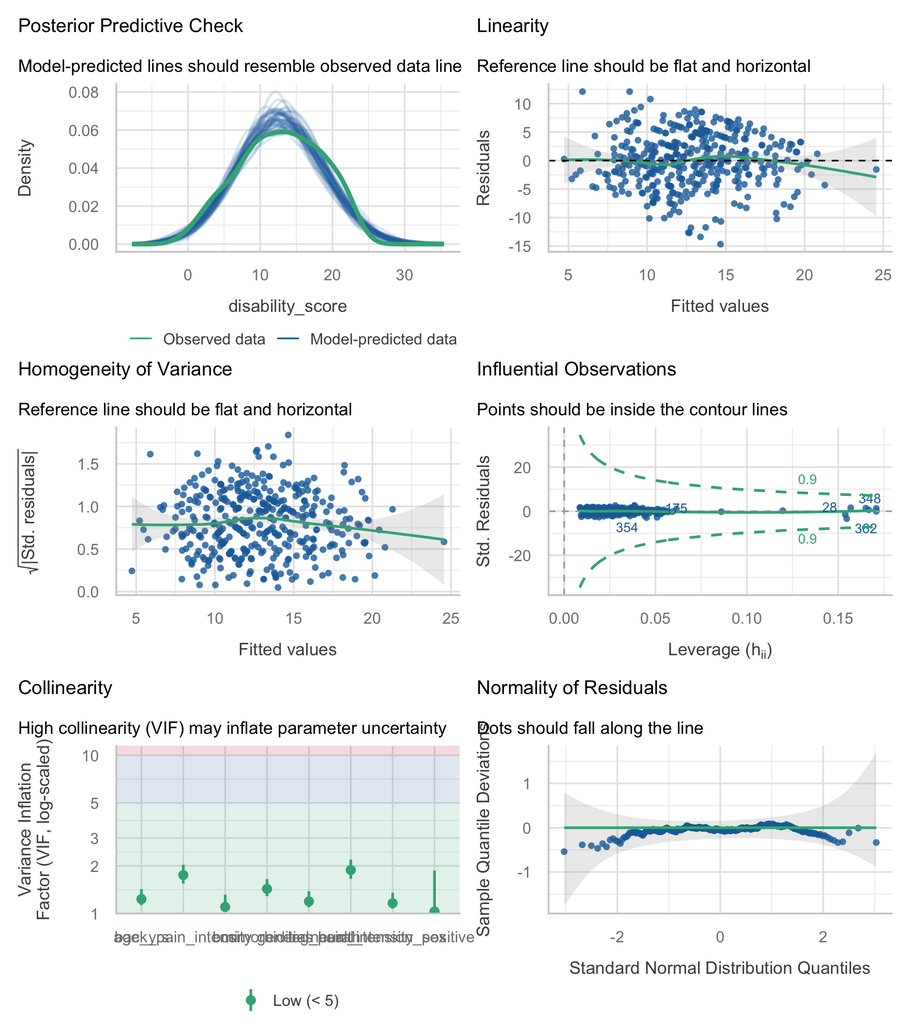

```
## OK: Error variance appears to be homoscedastic (p = 0.449).
```

```
## OK: residuals appear as normally distributed (p = 0.116).
```

| Term | VIF | VIF_CI_low | VIF_CI_high | SE_factor | Tolerance | Tolerance_CI_low | Tolerance_CI_high |
| --- | --- | --- | --- | --- | --- | --- | --- |
| age_yrs | 1.234044 | 1.128581 | 1.426007 | 1.110875 | 0.8103442 | 0.7012589 | 0.8860685 |
| sex | 1.030113 | 1.001044 | 1.868550 | 1.014945 | 0.9707675 | 0.5351744 | 0.9989571 |
| bmi | 1.100176 | 1.031906 | 1.314527 | 1.048893 | 0.9089452 | 0.7607301 | 0.9690805 |
| back_pain_intensity | 1.750727 | 1.546144 | 2.031946 | 1.323150 | 0.5711914 | 0.4921392 | 0.6467704 |
| leg_pain_intensity | 1.884189 | 1.655704 | 2.192291 | 1.372658 | 0.5307324 | 0.4561439 | 0.6039727 |
| general_health | 1.192320 | 1.096709 | 1.382459 | 1.044957 | 0.8387007 | 0.7233489 | 0.9118190 |
| comorbidities | 1.431867 | 1.286017 | 1.652092 | 1.093895 | 0.6983889 | 0.6052933 | 0.7775949 |
| neural_tension_positive | 1.162416 | 1.074537 | 1.353907 | 1.078154 | 0.8602772 | 0.7386033 | 0.9306338 |

```
## OK: No outliers detected.
## - Based on the following method and threshold: cook (0.9).
## - For variable: (Whole model)
```

**Linearity.** The fitted-versus-residual smooth is close to flat across the fitted range, and the posterior-predictive panel shows simulated data tracking the observed RMDQ distribution apart from a small pile-up at the scale ends – expected for a bounded 0-23 count.

**Homoscedasticity.** Constant variance is not rejected (`check_heteroscedasticity()` p = 0.449), so ordinary least-squares standard errors are reported as they stand and no HC3 re-estimation was required.

HC3 robust standard errors (sensitivity)

| Term | SE (OLS) | SE (HC3) | p (OLS) | p (HC3) |
| --- | --- | --- | --- | --- |
| (Intercept) | 1.645 | 1.516 | 0.107 | 0.080 |
| age_yrs | 0.019 | 0.020 | 0.007 | 0.009 |
| sexMale | 0.492 | 0.491 | 0.296 | 0.296 |
| bmi | 0.041 | 0.034 | 0.001 | 0.000 |
| back_pain_intensity | 0.145 | 0.151 | 0.000 | 0.000 |
| leg_pain_intensity | 0.135 | 0.146 | 0.001 | 0.002 |
| general_healthFair | 0.666 | 0.588 | 0.001 | 0.000 |
| general_healthPoor | 1.897 | 3.269 | 0.822 | 0.896 |
| comorbiditiesOne | 0.604 | 0.605 | 0.948 | 0.948 |
| comorbiditiesTwo or more | 0.881 | 0.903 | 0.815 | 0.820 |
| neural_tension_positiveYes | 0.524 | 0.564 | 0.004 | 0.008 |

**Normality of residuals.** Not rejected (`check_normality()` p = 0.116); the Q-Q plot is close to the reference line with mild thinning at both tails, which is what a bounded score produces.

**Influential points.** `check_outliers()` flags 0 observation(s) at the Cook’s-distance threshold, so no single patient is driving the fit.

**Collinearity.** All variance inflation factors are low; the largest is leg_pain_intensity at 1.88, far below the conventional concern threshold of 5. The two pain-intensity variables are correlated (r = 0.61) but not enough to destabilise their coefficients. This is the payoff of leaving `clinician_sciatica` out: a model containing it alongside the examination signs would have a substantially inflated VIF for `neural_tension_positive`, and including it here would have been indefensible.

# Discussion

Among primary-care patients presenting with sciatica, back-related disability is driven mainly by how much pain the patient reports, not by what the examination finds. Back-pain intensity and, to a lesser but still independent extent, leg-pain intensity account for most of the explained variance; higher BMI and a positive neural-tension test add modest independent increments, poorer self-rated general health adds a further intercept shift, and older patients report slightly *less* back-related disability once those are held constant. Practically, a GP who wants to know how disabled a sciatica patient is should ask about pain intensity and general health rather than rely on the neurological examination – and should not expect the answer to be very predictable, since 67% of the variance in RMDQ score is left unexplained by all eight predictors.

**Limitations.** The design is cross-sectional and every variable was recorded at the same consultation, so nothing here separates cause from consequence: a patient who cannot do their usual activities may well report higher pain because of that, rather than the reverse. `disability_score`, `back_pain_intensity`, `leg_pain_intensity` and `general_health` are all self-reported on the same occasion by the same person, so common-method bias inflates their associations and the R² of 0.33 is an optimistic ceiling. The RMDQ is a bounded 0-23 count with visible mass at both ends (5 patients scored 0 and 6 scored 23), so a linear model necessarily allows fitted values outside the achievable range for extreme covariate patterns; a count or beta-binomial model would respect the bounds, at the cost of interpretability. The `Poor` general-health category has only 7 patients, so its coefficient is essentially uninformative and its wide confidence interval should not be read as evidence of no effect. The file contains no measure of psychological distress, fear-avoidance beliefs or work status, all of which are established drivers of back-related disability, so residual confounding is likely. Complete-case analysis dropped only 2 rows here, but the same predictor set plus `leg_pain_duration` would drop 19 more. All estimates are associations, not causal effects.

**Future work.** Repeating the RMDQ at three months would show whether baseline pain intensity predicts *recovery* of function rather than merely correlating with concurrent function.

# Feasibility notes

*Not part of a student report.*